# Aprendizados Analíticos e Evidências a partir dos Dados de Câncer de Mama

GGAPP

2026-01-30

# 1 Introdução

Este documento sistematiza **aprendizados teóricos, metodológicos e empíricos** derivados de análises conduzidas no âmbito das iniciativas analíticas sobre câncer de mama, desenvolvidas no contexto da tentativa de estimar um modelo pré-exame voltado à priorização de atendimentos no sistema público de saúde, no qual a Prefeitura do Recife possui atuação direta.

A motivação central do trabalho está associada a um problema recorrente nas políticas de saúde: **como organizar fluxos assistenciais quando a demanda é maior que a capacidade instalada**, especialmente em contextos nos quais o diagnóstico precoce é determinante para a redução da mortalidade e para a melhoria dos desfechos clínicos. Nesse cenário, modelos de estratificação de risco surgem como instrumentos potenciais para apoiar decisões de priorização, desde que apresentem desempenho preditivo consistente e sejam viáveis do ponto de vista operacional e informacional.

O objetivo deste documento não é propor um modelo operacional definitivo, **mas registrar de forma sistemática as decisões analíticas tomadas, as limitações estruturais dos dados disponíveis e as lições aprendidas ao longo do processo de modelagem**. Trata-se, portanto, de um material voltado à **acumulação institucional de conhecimento**, com vistas a subsidiar futuras aplicações, replicações e aprimoramentos metodológicos, bem como a orientar decisões estratégicas sobre investimentos em dados, sistemas de informação e desenho de políticas públicas.

O documento segue o seguinte *road map* analítico:

> > Contextualização teórica: apresenta o debate sobre modelos de risco e estratégias de pré-exame no câncer de mama, destacando evidências da literatura sobre os limites e potenciais da estratificação de risco baseada em diferentes tipos de informação.

> > Teste empírico multibase: avalia, de forma sistemática, o desempenho de modelos de classificação estimados separadamente para diferentes bases do Registro Hospitalar de Câncer (RHC), utilizando exclusivamente variáveis pré-exame não mamárias.

> > Análise aprofundada de caso (RHC23): explora em maior detalhe o comportamento do modelo em uma base extensa, examinando métricas de desempenho, matriz de confusão e curva ROC.

> > Síntese dos aprendizados: consolida as evidências empíricas à luz da literatura, explicitando implicações analíticas, metodológicas e operacionais para estratégias de priorização no sistema público de saúde.

# 2 Contextualização Teórica: Risco, Pré-Exame e Antecipação Diagnóstica no Câncer de Mama

No debate sobre o câncer de mama, há discussões sobre modelos orientados ao pré-exame, reconhecendo que quanto mais cedo houver diagnóstico, menos haverá risco de fatalidade. Nesse contexto, ganha relevância a agenda de **estratificação de risco**, que busca apoiar decisões antes do exame diagnóstico, com foco em prevenção, triagem e organização de fluxos assistenciais.

Desse modo, modelos individualizados de risco podem apoiar estratégias de rastreamento, o que pode oferecer importantes contribuições para a formulação de políticas públicas de priorização. Revisões sistemáticas mostram que há um ecossistema amplo de modelos (incluindo ferramentas clássicas e modelos mais recentes), mas também destacam limitações recorrentes: heterogeneidade de populações, variação de desempenho discriminativo, diferenças nos conjuntos de variáveis disponíveis e desafios de implementação em contextos reais de serviços (Louro et al. 2019).

Entre os determinantes e marcadores do risco, a literatura destaca que a **densidade mamária** é um fator importante e muito associado ao risco futuro de desenvolvimento do câncer e pode ser operacionalizada por métricas distintas para classificações do *BI-RADS*, o que pode contribuir para estratégias de priorização e triagem (Jeffers et al. 2017).

Para projetos que miram o pré-exame, a literatura também aponta um limite importante: **os ganhos preditivos mais relevantes emergem apenas quando os modelos incorporam informações diretamente relacionadas à mama ou a marcadores biológicos do processo de adoecimento.** Quando restritos a variáveis não mamárias — como características sociodemográficas, históricos clínicos gerais ou fatores comportamentais e metabólicos —, os modelos tendem a apresentar **baixo poder discriminativo, desempenho instável e utilidade limitada para priorização individualizada.**

Modelos preditivos baseados em informações gerais, como idade, histórico reprodutivo, antecedentes clínicos e fatores comportamentais — tendem a apresentar desempenho apenas moderado, com grande variação entre populações e forte dependência do conjunto de variáveis disponíveis (Louro et al. 2019). O desempenho do modelo melhora à medida que outras variáveis são incorporadas, principalmente no tocante a informações mais próximas do fenômeno biológico do câncer de mama, como densidade mamária e componentes genéticos, enquanto modelos mais “distantes” do tecido mamário apresentam utilidade limitada para decisões individualizadas.

Empiricamente, evidencia-se também que a densidade mamária é um fator central para a identificação do risco. Diferentes métricas de densidade mamária — avaliadas por métodos semiautomatizados, automatizados e classificações BI-RADS — estão fortemente associadas ao risco futuro de desenvolvimento do câncer de mama. A implicação direta desse achado é que informações mamárias não são apenas complementares, mas estruturais para a capacidade preditiva dos modelos. Na ausência desse tipo de variável, o potencial de estratificação de risco é significativamente reduzido (Jeffers et al. 2017).

A incorporação de informações genéticas reforçam esse argumento. Os *polygenic risk scores (PRS)* ampliam a capacidade de previsão de risco ao capturar predisposições biológicas que não são observáveis por variáveis clínicas ou sociodemográficas convencionais. Ainda que esses instrumentos apresentem desafios de implementação e questões éticas, sua recorrente associação a melhorias no desempenho dos modelos sugere que a informação biológica é um componente-chave para qualquer estratégia robusta de estratificação de risco (Roberts, Howell, and Evans 2023).

Mesmo abordagens baseadas em grandes volumes de dados e aprendizado de máquina não escapam desse limite. Modelos que utilizam dados pessoais de saúde e *machine learning* mostram que ganhos incrementais de desempenho dependem de variáveis clínicas próximas do tecido mamário (Stark et al. 2019). Adicionalmente, modelos de previsão de curto prazo baseados em grandes bases clínicas mostram que é possível antecipar o risco de desenvolvimento do câncer de mama em horizontes temporais reduzidos,desde que existam históricos clínicos densos e acumulados em prontuários eletrônicos (Feinstein et al. 2025).

**Lição teórica central do projeto**

Em outras palavras, a evidência acumulada na literatura indica que há um limite estrutural para modelos de priorização baseados exclusivamente em variáveis pré-exame não mamárias. Ainda que informações sociodemográficas, clínicas gerais ou comportamentais contribuam para análises descritivas e para a compreensão do risco em nível agregado, elas não são suficientes para sustentar modelos individualizados com desempenho discriminativo adequado.

**A disponibilidade de dados clínicos diretamente relacionados à mama ou de informações biológicas é condição necessária para a utilidade preditiva de estratégias de estratificação de risco.**

# 3 Teste empírico

A seção empírica tem como objetivo avaliar, de forma sistemática, o desempenho de modelos de classificação baseados **exclusivamente em variáveis pré-exame não mamárias**, aplicados a diferentes bases do Registro Hospitalar de Câncer (RHC). A estratégia adotada consistiu em estimar, separadamente para cada base anual, um modelo preditivo capaz de distinguir casos reais de câncer de mama (C50) de um grupo de controle sintético, construído por reamostragem das próprias observações, utilizando apenas informações sociodemográficas, comportamentais e clínicas gerais disponíveis antes da realização de qualquer exame relacionado à mama.

A métrica principal de avaliação foi a *Area Under the Curve (AUC)*, que mensura a capacidade discriminativa do modelo em diferenciar corretamente indivíduos classificados como “risco” e “não risco” no conjunto de teste. Adicionalmente, são apresentadas as proporções de observações classificadas em cada grupo, de modo a facilitar a leitura substantiva dos resultados. A análise contempla bases com tamanhos amostrais bastante heterogêneos, permitindo observar tanto o comportamento do modelo em contextos com grande volume de dados quanto em bases com número reduzido de casos, estas últimas devidamente sinalizadas ao longo da apresentação dos resultados.

## 3.1 Desempenho do modelo pré-exame por base RHC

A Tabela apresenta o desempenho do modelo pré-exame estimado para cada base do RHC, medido pela AUC no conjunto de teste, bem como a proporção de observações classificadas como “risco” e “não risco”. Observa-se, inicialmente, que bases com número muito reduzido de casos de câncer de mama (C50) tendem a apresentar valores de AUC artificialmente elevados ou instáveis, como nos casos de rhc94 e rhc95, o que reflete limitações amostrais severas e impede qualquer interpretação substantiva desses resultados.

Nas bases com maior número de casos — especialmente aquelas com dezenas de milhares de registros — o desempenho do modelo se mostra notavelmente consistente, com valores de AUC concentrados em torno de **0,68 a 0,71.** Esses resultados indicam uma capacidade discriminativa apenas **moderada**, ligeiramente superior ao acaso (AUC = 0,5), **mas insuficiente para sustentar decisões robustas de priorização individual em contextos operacionais**. Além disso, as proporções de classificações como “risco” e “não risco” permanecem próximas ao equilíbrio, sugerindo que **o modelo tem dificuldade em separar de forma clara indivíduos com maior e menor probabilidade de pertencimento ao grupo de interesse.**

```r
# ============================================================
# SEÇÃO EMPÍRICA — MODELO PRÉ-EXAME (RHC / DBF) + OUTPUT BONITO (HTML)
# - Lê bases .dbf
# - Filtra C50
# - Monta controle sintético (bootstrap)
# - Treina ranger (RF) e calcula AUC
# - Gera tabelas (gt) + gráfico (ggplot) prontos pro HTML
# ============================================================

# Pacotes
library(foreign)
library(tidyverse)
library(pROC)
library(ranger)
library(purrr)
library(janitor)
library(gt)
library(scales)
library(rlang)

# ============================================================
# FUNÇÃO PRINCIPAL PARA PROCESSAR UMA BASE RHC
# ============================================================
rodar_modelo_rhc <- function(arquivo) {

  message("\n=== Processando: ", basename(arquivo), " ===")

  # ----------------------------------------------------------
  # 1) Ler base e filtrar C50
  # ----------------------------------------------------------
  df <- read.dbf(arquivo, as.is = TRUE) %>%
    as_tibble()

  # Algumas bases vêm em UPPERCASE; manter como está (evita quebrar)
  if (!"LOCTUDET" %in% names(df)) {
    warning("Coluna LOCTUDET não encontrada em: ", basename(arquivo))
    return(list(base = basename(arquivo), auc = NA, erro = "Sem LOCTUDET"))
  }

  df <- df %>% filter(LOCTUDET == "C50")

  # Se base já ficou muito pequena logo no filtro
  if (nrow(df) < 10) {
    warning("Base com poucos registros após filtro C50: ", basename(arquivo))
    return(list(base = basename(arquivo), auc = NA, erro = "Poucos C50"))
  }

  # ----------------------------------------------------------
  # 2) Selecionar variáveis pré-exame
  # (somente variáveis gerais; nenhuma variável mamária)
  # ----------------------------------------------------------
  vars_pre <- c(
    "IDADE", "SEXO", "RACACOR", "INSTRUC", "OCUPACAO",
    "ESTCONJ", "PROCEDEN", "ESTADRES", "LOCALNAS",
    "TABAGISM", "ALCOOLIS"
  )

  vars_pre <- intersect(vars_pre, names(df))

  if (length(vars_pre) < 3) {
    warning("Poucas variáveis disponíveis para modelar em: ", basename(arquivo))
    return(list(base = basename(arquivo), auc = NA, erro = "Poucas variáveis"))
  }

  df_pre <- df %>%
    select(all_of(vars_pre)) %>%
    drop_na()

  # Se ficar vazio depois da limpeza → retornar erro
  if (nrow(df_pre) < 10) {
    warning("Base com poucos registros após limpeza: ", basename(arquivo))
    return(list(base = basename(arquivo), auc = NA, erro = "Poucos dados"))
  }

  # ----------------------------------------------------------
  # 3) Tipos: fatores + idade numérica
  # ----------------------------------------------------------
  df_pre <- df_pre %>%
    mutate(across(everything(), ~ if (is.character(.x)) as.factor(.x) else .x)) %>%
    mutate(across(where(is.logical), as.factor)) %>%
    mutate(across(where(is.factor), droplevels))

  if ("IDADE" %in% names(df_pre)) {
    df_pre$IDADE <- suppressWarnings(as.numeric(as.character(df_pre$IDADE)))
  }

  # ----------------------------------------------------------
  # 4) Controle sintético (bootstrap) seguro
  # ----------------------------------------------------------
  set.seed(123)
  df_fake <- df_pre[sample(1:nrow(df_pre), nrow(df_pre), replace = TRUE), ]

  # ----------------------------------------------------------
  # 5) Combinar dados reais (y=1) e sintéticos (y=0)
  # ----------------------------------------------------------
  df_all <- bind_rows(
    df_pre  %>% mutate(y = 1),
    df_fake %>% mutate(y = 0)
  )

  df_all$y <- factor(df_all$y, levels = c(0, 1))

  # ----------------------------------------------------------
  # 6) Train/test split estratificado
  # ----------------------------------------------------------
  idx_1 <- which(df_all$y == 1)
  idx_0 <- which(df_all$y == 0)

  train_1 <- sample(idx_1, floor(0.8 * length(idx_1)))
  train_0 <- sample(idx_0, floor(0.8 * length(idx_0)))

  train_idx <- c(train_1, train_0)
  test_idx  <- setdiff(1:nrow(df_all), train_idx)

  train <- df_all[train_idx, , drop = FALSE]
  test  <- df_all[test_idx, , drop = FALSE]

  # Ajustar níveis dos fatores no teste
  for (col in names(train)) {
    if (is.factor(train[[col]])) {
      test[[col]] <- factor(test[[col]], levels = levels(train[[col]]))
    }
  }

  # Garantir 2 classes no teste
  if (length(unique(test$y)) < 2) {
    warning("TESTE sem as duas classes: ", basename(arquivo))
    return(list(base = basename(arquivo), auc = NA, erro = "Teste sem 2 classes"))
  }

  # ----------------------------------------------------------
  # 7) Modelo ranger
  # ----------------------------------------------------------
  modelo <- ranger(
    y ~ .,
    data = train,
    num.trees = 300,
    probability = TRUE,
    respect.unordered.factors = "order"
  )

  preds <- predict(modelo, test)$predictions

  # ranger deve retornar 2 colunas de probabilidade
  if (!is.matrix(preds) || ncol(preds) != 2) {
    warning("Predição sem 2 colunas: ", basename(arquivo))
    return(list(base = basename(arquivo), auc = NA, erro = "Predição com 1 coluna"))
  }

  prob1 <- preds[, 2]

  # ----------------------------------------------------------
  # 8) AUC
  # ----------------------------------------------------------
  auc_val <- tryCatch(
    as.numeric(pROC::auc(test$y, prob1)),
    error = function(e) NA_real_
  )

  # ----------------------------------------------------------
  # 9) Predição binária
  # ----------------------------------------------------------
  pred_class <- ifelse(prob1 > 0.5, 1, 0)

  # ----------------------------------------------------------
  # 10) Resultados
  # ----------------------------------------------------------
  classificacoes <- test %>%
    mutate(prob = prob1, class = pred_class)

  # matriz de confusão (2x2) mais “amigável”
  tab_conf <- table(Predito = pred_class, Real = test$y)

  return(list(
    base = basename(arquivo),
    auc = auc_val,
    pct_risco = mean(pred_class == 1),
    pct_nao_risco = mean(pred_class == 0),
    tabela_conf = tab_conf,
    classificacoes = classificacoes,
    n_c50 = nrow(df_pre)
  ))
}

# ============================================================
# RODAR EM TODAS AS BASES
# ============================================================

caminho <- "data/irhc/"
arquivos <- list.files(
  caminho,
  pattern = "^rhc[0-9]+\\.dbf$",
  full.names = TRUE
)

if (length(arquivos) == 0) {
  stop("Nenhum arquivo encontrado em ", caminho, " com o padrão ^rhc[0-9]+\\.dbf$")
}

resultados <- lapply(arquivos, rodar_modelo_rhc)
```

```r
# ============================================================
# TABELA FINAL (COMPARAÇÃO ENTRE BASES)
# ============================================================

comparacao <- tibble(
  base = map_chr(resultados, ~ .x$base %||% NA_character_),
  auc  = map_dbl(resultados, ~ as.numeric(.x$auc %||% NA_real_)),
  pct_risco = map_dbl(resultados, ~ as.numeric(.x$pct_risco %||% NA_real_)),
  pct_nao_risco = map_dbl(resultados, ~ as.numeric(.x$pct_nao_risco %||% NA_real_)),
  n_c50 = map_dbl(resultados, ~ as.numeric(.x$n_c50 %||% NA_real_)),
  erro = map_chr(resultados, ~ .x$erro %||% NA_character_)
) %>%
  mutate(
    base_clean = str_replace(base, "\\.dbf$", "")
  )

# Só o que é plotável (AUC calculável)
comparacao_plot <- comparacao %>%
  filter(!is.na(auc)) %>%
  mutate(
    label_n = ifelse(!is.na(n_c50) & n_c50 < 30, paste0("n=", n_c50), NA_character_)
  )

# ============================================================
# OUTPUT BONITO: TABELA GT (HTML)
# ============================================================

comparacao %>%
  mutate(
    auc = round(auc, 3),
    pct_risco = round(100 * pct_risco, 1),
    pct_nao_risco = round(100 * pct_nao_risco, 1)
  ) %>%
  arrange(desc(auc)) %>%
  select(Base = base_clean, `n (C50)` = n_c50, AUC = auc,
         `% risco (teste)` = pct_risco, `% não risco (teste)` = pct_nao_risco,
         `Obs.` = erro) %>%
  gt() %>%
  tab_header(
    title = "Desempenho do modelo pré-exame por base RHC",
    subtitle = "AUC e proporção de classificações no conjunto de teste"
  ) %>%
  fmt_number(columns = c(AUC), decimals = 3) %>%
  fmt_number(columns = c(`% risco (teste)`, `% não risco (teste)`), decimals = 1) %>%
  data_color(
    columns = AUC,
    palette = c("#f7fbff", "#08306b")
  ) %>%
  tab_options(
    table.font.size = px(14),
    heading.title.font.size = px(18),
    heading.subtitle.font.size = px(13)
  ) %>%
  tab_source_note(
    source_note = "Nota: AUC=0,5 indica desempenho equivalente ao acaso; valores mais altos indicam maior discriminação."
  )
```

Desempenho do modelo pré-exame por base RHC

AUC e proporção de classificações no conjunto de teste

| Base | n (C50) | AUC | % risco (teste) | % não risco (teste) | Obs. |
| --- | --- | --- | --- | --- | --- |
| rhc94 | 16 | 0.844 | 37.5 | 62.5 | NA |
| rhc99 | 641 | 0.736 | 42.6 | 57.4 | NA |
| rhc95 | 23 | 0.720 | 40.0 | 60.0 | NA |
| rhc17 | 48732 | 0.705 | 48.1 | 51.9 | NA |
| rhc19 | 52791 | 0.699 | 47.7 | 52.3 | NA |
| rhc22 | 48756 | 0.698 | 47.1 | 52.9 | NA |
| rhc07 | 27586 | 0.697 | 47.6 | 52.4 | NA |
| rhc10 | 38064 | 0.695 | 46.8 | 53.2 | NA |
| rhc11 | 40660 | 0.695 | 47.0 | 53.0 | NA |
| rhc13 | 45438 | 0.695 | 49.0 | 51.0 | NA |
| rhc23 | 19003 | 0.694 | 47.0 | 53.0 | NA |
| rhc14 | 45731 | 0.691 | 46.8 | 53.2 | NA |
| rhc09 | 36806 | 0.689 | 46.4 | 53.6 | NA |
| rhc00 | 11854 | 0.688 | 46.7 | 53.3 | NA |
| rhc06 | 23754 | 0.688 | 46.9 | 53.1 | NA |
| rhc08 | 31308 | 0.688 | 47.9 | 52.1 | NA |
| rhc05 | 22749 | 0.686 | 47.3 | 52.7 | NA |
| rhc01 | 14874 | 0.683 | 46.4 | 53.6 | NA |
| rhc04 | 20119 | 0.681 | 47.9 | 52.1 | NA |
| rhc02 | 17554 | 0.676 | 48.7 | 51.3 | NA |
| rhc03 | 18786 | 0.674 | 46.2 | 53.8 | NA |
| rhc93 | 14 | 0.667 | 83.3 | 16.7 | NA |
| rhc98 | 270 | 0.638 | 50.0 | 50.0 | NA |
| rhc96 | 33 | 0.592 | 71.4 | 28.6 | NA |
| rhc97 | 52 | 0.421 | 63.6 | 36.4 | NA |
| rhc85 | NA | NA | NA | NA | Poucos C50 |
| rhc86 | NA | NA | NA | NA | Poucos C50 |
| rhc88 | NA | NA | NA | NA | Poucos C50 |
| rhc89 | NA | NA | NA | NA | Poucos C50 |
| rhc90 | NA | NA | NA | NA | Poucos C50 |
| rhc91 | NA | NA | NA | NA | Poucos C50 |
| rhc92 | NA | NA | NA | NA | Poucos C50 |

Nota: AUC=0,5 indica desempenho equivalente ao acaso; valores mais altos indicam maior discriminação.

O gráfico apresenta o desempenho do modelo pré-exame, medido pela AUC no conjunto de teste, para múltiplas bases do Registro Hospitalar de Câncer (RHC). Observa-se que, nas bases com maior número de casos de câncer de mama, os valores de AUC se concentram em uma faixa estreita, aproximadamente entre 0,68 e 0,71, indicando uma capacidade discriminativa apenas moderada e consistentemente próxima desse patamar. A linha tracejada em AUC = 0,5 indica o desempenho equivalente ao acaso, evidenciando que, embora o modelo supere esse limiar, o ganho preditivo permanece limitado mesmo em contextos com grande volume de dados.

As bases com número muito reduzido de casos, explicitamente sinalizadas no gráfico, apresentam valores de AUC mais extremos, tanto acima quanto abaixo do padrão observado nas bases maiores. Esse comportamento reflete a instabilidade esperada de métricas de desempenho em amostras pequenas, nas quais flutuações aleatórias podem inflar ou depreciar artificialmente a AUC. Assim, valores elevados observados nessas bases não devem ser interpretados como evidência de melhor desempenho estrutural do modelo.

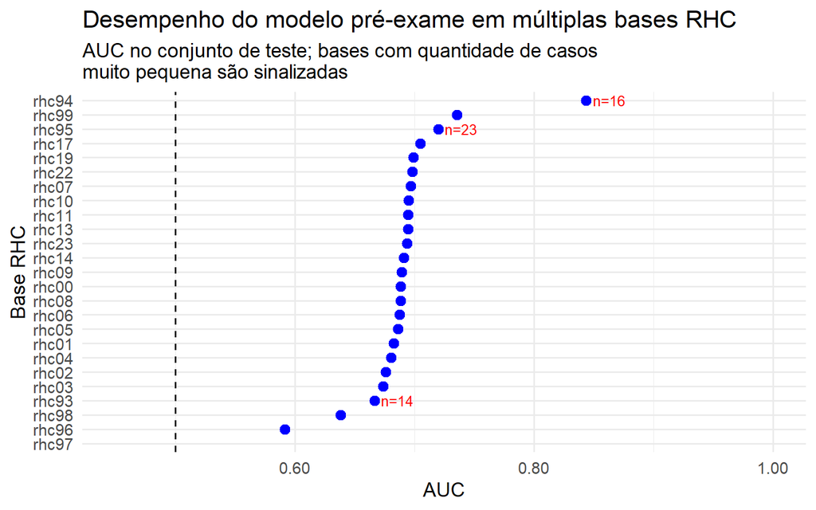

```r
# ============================================================
# OUTPUT BONITO: GRÁFICO AUC (HTML)
# ============================================================

if (nrow(comparacao_plot) > 0) {
  ggplot(comparacao_plot, aes(x = reorder(base_clean, auc), y = auc)) +
    geom_point(size = 3, color = "blue") +
    geom_hline(yintercept = 0.5, linetype = "dashed") +
    geom_text(
    aes(label = label_n),
    hjust = -0.2,
    vjust = 0.5,
    size = 3.5,
    color = "red",
    na.rm = TRUE)+
    coord_flip() +
    scale_y_continuous(limits = c(0.45, 1), labels = label_number(accuracy = 0.01)) +
    labs(
      title = "Desempenho do modelo pré-exame em múltiplas bases RHC",
      subtitle = "AUC no conjunto de teste; bases com quantidade de casos \nmuito pequena são sinalizadas",
      x = "Base RHC",
      y = "AUC"
    ) +
    theme_minimal(base_size = 14)
} else {
  message("Nenhuma base com AUC calculável para plot.")
}
```

## 3.2 Avaliação Empírica do Modelo Pré-Exame com Grupo de Comparação Derivado dos Casos

Nesta etapa, foi estimado um modelo preditivo para a base **RHC23**, restringindo-se aos registros com diagnóstico **(câncer de mama)**. A modelagem foi conduzida exclusivamente com **variáveis pré-exame não mamárias** (idade, sexo e indicadores gerais como tabagismo, consumo de álcool e histórico familiar). Como não há, nesse recorte, um grupo observacional “não câncer” diretamente comparável dentro da mesma estrutura, foi construído um **grupo de controle sintético** por reamostragem (*bootstrap*) das próprias observações, de modo a permitir um exercício de separação entre um grupo “caso” e um grupo “controle” com distribuição semelhante das covariáveis.

Em seguida, os dados combinados foram divididos em conjuntos de treino e teste (80/20), e foi ajustado um modelo de *Random Forest* (`ranger`) com saída probabilística. O desempenho foi avaliado principalmente pela **AUC** no conjunto de teste, complementada pela **curva ROC**, matriz de confusão e métricas derivadas de classificação binária (precision, recall e F1), além da proporção de observações classificadas como “risco” sob o limiar padrão de 0,5.

A tabela apresenta o desempenho do modelo pré-exame estimado para a base RHC23, utilizando exclusivamente variáveis não mamárias e um grupo de comparação derivado dos próprios casos. O valor de **AUC igual a 0,524** indica que a capacidade discriminativa do modelo **é apenas marginalmente superior ao acaso**, sugerindo que o conjunto de variáveis utilizadas tem poder muito limitado para distinguir, de forma consistente, indivíduos classificados como “risco” e “não risco” no conjunto de teste.

As métricas de classificação complementares reforçam essa leitura. Embora **o recall relativamente elevado (0,635)** indique que o modelo consegue recuperar uma parcela considerável dos casos classificados como “risco”, esse desempenho ocorre à custa de **baixa precisão (0,481)**, o que implica um elevado número de falsos positivos. O valor intermediário do F1 (0,547) reflete exatamente esse trade-off: o modelo tende a identificar muitos indivíduos como “risco”, mas com baixa capacidade de separação efetiva entre os grupos.

Esse comportamento também se manifesta na distribuição das classificações, com **65,4% das observações sendo classificadas como “risco”, evidenciando um viés do modelo em direção à classe positiva sob o limiar padrão de 0,5.** Em conjunto, os resultados indicam que, mesmo em uma base extensa como a RHC23, o modelo pré-exame baseado apenas em variáveis não mamárias apresenta desempenho fraco e utilidade limitada para fins de priorização individual.

```r
# ============================================================
# MODELO PRÉ-EXAME — RHC23 (C50) | Variáveis não-mamárias
# Outputs: Tabela (gt) + Curva ROC (ggplot) + Métricas
# ============================================================

library(foreign)
library(tidyverse)
library(pROC)
library(ranger)
library(gt)
library(scales)

# ------------------------------
# 1) Ler base e filtrar C50
# ------------------------------
df <- read.dbf("data/irhc/rhc23.dbf", as.is = TRUE) %>%
  as_tibble()

df <- df %>% filter(LOCTUDET == "C50")

# ------------------------------
# 2) Selecionar variáveis pré-exame
# ------------------------------
vars_pre <- c(
  "IDADE",
  "SEXO",
  "TABAGISM",
  "ALCOOLIS",
  "HISTFAMC"
)

vars_pre <- intersect(vars_pre, names(df))

df_pre <- df %>%
  select(all_of(vars_pre)) %>%
  drop_na()

# categóricas -> factor
df_pre <- df_pre %>%
  mutate(across(where(~ !is.numeric(.x)), as.factor))

# idade -> numérica (se vier como fator/char)
if ("IDADE" %in% names(df_pre)) {
  df_pre$IDADE <- suppressWarnings(as.numeric(as.character(df_pre$IDADE)))
}

# Checagem mínima
stopifnot(nrow(df_pre) >= 10)

# ------------------------------
# 3) Criar controle sintético (bootstrap)
# ------------------------------
make_synth_realistic <- function(df) {
  df[sample(nrow(df), nrow(df), replace = TRUE), ]
}

set.seed(123)
df_fake <- make_synth_realistic(df_pre)

# juntar casos reais + controles
df_all <- bind_rows(
  df_pre  %>% mutate(y = 1),
  df_fake %>% mutate(y = 0)
)

df_all$y <- factor(df_all$y, levels = c(0, 1))

# ------------------------------
# 4) Treino / Teste
# ------------------------------
set.seed(123)
n <- nrow(df_all)
idx <- sample(seq_len(n), size = floor(0.8 * n))

train <- df_all[idx, , drop = FALSE]
test  <- df_all[-idx, , drop = FALSE]

# Garantir níveis de fatores no teste
for (col in names(train)) {
  if (is.factor(train[[col]])) {
    test[[col]] <- factor(test[[col]], levels = levels(train[[col]]))
  }
}

# ------------------------------
# 5) Modelo (ranger)
# ------------------------------
modelo <- ranger(
  y ~ .,
  data = train,
  num.trees = 300,
  probability = TRUE,
  respect.unordered.factors = "order"
)

pred_prob <- predict(modelo, test)$predictions[, 2]

# ------------------------------
# 6) Métricas: AUC + ROC
# ------------------------------
roc_obj <- pROC::roc(test$y, pred_prob, quiet = TRUE)
auc_val <- as.numeric(pROC::auc(roc_obj))

# classificação binária (threshold 0.5)
pred_class <- ifelse(pred_prob > 0.5, 1, 0)

# matriz de confusão
conf_mat <- table(Predito = pred_class, Real = test$y)

# proporções
pct_risco <- mean(pred_class == 1)
pct_nao_risco <- mean(pred_class == 0)

# precision / recall / f1
real01 <- as.integer(as.character(test$y))
pred01 <- as.integer(pred_prob > 0.5)

TP <- sum(pred01 == 1 & real01 == 1)
FP <- sum(pred01 == 1 & real01 == 0)
FN <- sum(pred01 == 0 & real01 == 1)

precision <- TP / (TP + FP)
recall    <- TP / (TP + FN)
f1        <- 2 * precision * recall / (precision + recall)

# ------------------------------
# 7) TABELA BONITA — Métricas
# ------------------------------
tibble(
  Base = "rhc23",
  `n (C50, após limpeza)` = nrow(df_pre),
  `AUC (teste)` = auc_val,
  `Precision` = precision,
  `Recall` = recall,
  `F1` = f1,
  `% classificado como risco` = pct_risco,
  `% classificado como não risco` = pct_nao_risco
) %>%
  mutate(
    across(where(is.numeric), ~ as.numeric(.x)),
    `AUC (teste)` = round(`AUC (teste)`, 3),
    Precision = round(Precision, 3),
    Recall = round(Recall, 3),
    F1 = round(F1, 3),
    `% classificado como risco` = round(100 * `% classificado como risco`, 1),
    `% classificado como não risco` = round(100 * `% classificado como não risco`, 1)
  ) %>%
  gt() %>%
  tab_header(
    title = "Desempenho do modelo pré-exame — RHC23",
    subtitle = "Métricas no conjunto de teste (threshold = 0,5)"
  ) %>%
  cols_label(
    Base = "Base",
    `n (C50, após limpeza)` = "n (C50)",
    `AUC (teste)` = "AUC",
    `% classificado como risco` = "% risco",
    `% classificado como não risco` = "% não risco"
  ) %>%
  tab_options(
    table.font.size = px(14),
    heading.title.font.size = px(18),
    heading.subtitle.font.size = px(13)
  ) %>%
  tab_source_note(
    source_note = "Nota: AUC=0,5 indica desempenho equivalente ao acaso; F1 resume o equilíbrio entre precision e recall."
  )
```

Desempenho do modelo pré-exame — RHC23

Métricas no conjunto de teste (threshold = 0,5)

| Base | n (C50) | AUC | Precision | Recall | F1 | % risco | % não risco |
| --- | --- | --- | --- | --- | --- | --- | --- |
| rhc23 | 19003 | 0.524 | 0.481 | 0.635 | 0.547 | 65.4 | 34.6 |

Nota: AUC=0,5 indica desempenho equivalente ao acaso; F1 resume o equilíbrio entre precision e recall.

A matriz de confusão detalha o padrão de erros e acertos do modelo no conjunto de teste, permitindo compreender de forma mais concreta as limitações observadas nas métricas agregadas. Nota-se que o modelo classifica um volume expressivo de observações como “risco”, resultando em **2.580 falsos positivos**, isto é, indivíduos classificados como risco que pertencem ao grupo de comparação (“não risco”). Esse comportamento explica diretamente o valor reduzido da precisão observado na tabela de desempenho.

Ao mesmo tempo, o modelo consegue identificar uma parcela relevante dos casos **classificados como risco (2.389 verdadeiros positivos)**, o que sustenta o recall relativamente elevado. Contudo, essa capacidade de sensibilidade vem acompanhada de uma taxa igualmente elevada de erros de classificação, com **1.371 falsos negativos**, indicando que uma fração significativa dos casos de interesse ainda é classificada como “não risco”.

```r
# ------------------------------
# 8) TABELA BONITA — Matriz de confusão
# ------------------------------
conf_df <- as.data.frame.matrix(conf_mat) %>%
  rownames_to_column("Predito") %>%
  as_tibble() %>%
  mutate(Predito = recode(Predito, `0` = "Não risco", `1` = "Risco")) %>%
  rename(`Real: Não risco (0)` = `0`, `Real: Risco (1)` = `1`)

conf_df %>%
  gt() %>%
  tab_header(
    title = "Matriz de confusão — RHC23",
    subtitle = "Predição binária (threshold = 0,5)"
  ) %>%
  tab_options(table.font.size = px(14))
```

Matriz de confusão — RHC23

Predição binária (threshold = 0,5)

| Predito | Real: Não risco (0) | Real: Risco (1) |
| --- | --- | --- |
| Não risco | 1262 | 1371 |
| Risco | 2580 | 2389 |

A curva ROC ilustra graficamente o desempenho do modelo pré-exame ao relacionar a taxa de verdadeiros positivos (sensibilidade) com a taxa de falsos positivos (1 − especificidade) para diferentes limiares de classificação. No caso da base RHC23, observa-se que a curva permanece muito próxima da diagonal de referência, que representa um classificador com desempenho equivalente ao acaso.

O valor de **AUC = 0,524** confirma essa leitura visual, indicando que o modelo apresenta apenas um ganho marginal de discriminação em relação a uma classificação aleatória. Em termos práticos, isso significa que, ao comparar aleatoriamente um indivíduo classificado como “risco” com um indivíduo classificado como “não risco”, o modelo tem pouco mais de 52% de chance de atribuir uma probabilidade maior ao caso correto, o que é insuficiente para sustentar decisões de priorização individual.

Além disso, o formato da curva evidencia que **não há um limiar de classificação capaz de produzir simultaneamente alta sensibilidade e alta especificidade.** Qualquer tentativa de aumentar a taxa de verdadeiros positivos implica um crescimento quase proporcional da taxa de falsos positivos, reforçando a ideia de que o modelo não consegue separar adequadamente os grupos ao longo de todo o espectro de probabilidades.

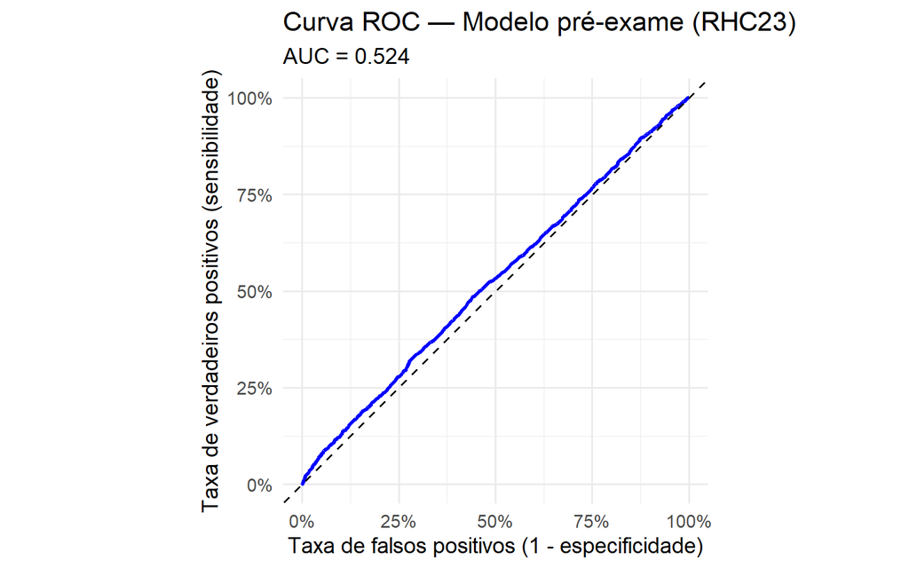

```r
# ------------------------------
# 9) GRÁFICO BONITO — Curva ROC
# ------------------------------
roc_df <- tibble(
  fpr = 1 - roc_obj$specificities,
  tpr = roc_obj$sensitivities
)

ggplot(roc_df, aes(x = fpr, y = tpr)) +
  geom_line(linewidth = 1.2, color='blue') +
  geom_abline(linetype = "dashed") +
  coord_equal() +
  scale_x_continuous(labels = percent_format(accuracy = 1)) +
  scale_y_continuous(labels = percent_format(accuracy = 1)) +
  labs(
    title = "Curva ROC — Modelo pré-exame (RHC23)",
    subtitle = paste0("AUC = ", round(auc_val, 3)),
    x = "Taxa de falsos positivos (1 - especificidade)",
    y = "Taxa de verdadeiros positivos (sensibilidade)"
  ) +
  theme_minimal(base_size = 14)
```

# 4 Considerações finais

Os resultados apresentados ao longo deste documento convergem para uma conclusão clara e consistente: modelos de estratificação de risco baseados exclusivamente em variáveis pré-exame não mamárias apresentam limites estruturais severos para fins de priorização individual no câncer de mama.

Do ponto de vista empírico, os testes realizados em múltiplas bases do Registro Hospitalar de Câncer mostram que, mesmo em contextos com grande volume de dados, o desempenho discriminativo dos modelos permanece restrito a uma faixa moderada (AUC em torno de 0,68–0,71), enquanto análises mais detalhadas — como o exercício conduzido com a base RHC23 — indicam desempenho apenas marginalmente superior ao acaso (AUC ≈ 0,52). Esses resultados se manifestam, de forma consistente, em padrões de classificação caracterizados por alta taxa de falsos positivos, baixa precisão e dificuldade em separar claramente indivíduos de maior e menor risco.

Essas evidências empíricas dialogam diretamente com a literatura revisada. Tanto estudos clássicos quanto abordagens mais recentes em machine learning apontam que ganhos preditivos relevantes dependem da incorporação de informações diretamente relacionadas ao tecido mamário ou a marcadores biológicos do processo de adoecimento, como densidade mamária, achados de imagem ou componentes genéticos. Na ausência desse tipo de dado, os modelos tendem a operar próximos a um limite informacional, no qual incrementos metodológicos não se traduzem em melhorias substantivas de desempenho.

**Do ponto de vista das políticas públicas, a implicação central é que modelos pré-exame baseados apenas em variáveis gerais não devem ser utilizados como instrumentos decisórios para priorização individual de atendimentos, sob risco de gerar filas artificialmente infladas, desperdício de capacidade assistencial e potenciais distorções de equidade.**

Seu uso, quando muito, deve ser restrito a análises exploratórias, descrições agregadas de perfil de risco ou exercícios metodológicos internos.

Ao mesmo tempo, os resultados oferecem uma contribuição positiva e orientadora: eles ajudam a esclarecer quais investimentos são necessários para que estratégias de estratificação de risco se tornem viáveis e úteis. A incorporação de dados clínicos mamários, a integração de sistemas de informação diagnóstica e, eventualmente, o uso responsável de informações biológicas são condições centrais para qualquer avanço substantivo nessa agenda.

# Referências

Feinstein, O. et al. 2025. “Short-Term Prediction Model for Breast Cancer Risk Based on One Million Medical Records.” *Clinical Breast Cancer*.

Jeffers, A. M. et al. 2017. “Breast Cancer Risk and Mammographic Density Assessed with Semiautomated and Fully Automated Methods and BI-RADS.” *Radiology* 282 (2): 348–55.

Louro, J. et al. 2019. “A Systematic Review and Quality Assessment of Individualised Breast Cancer Risk Prediction Models.” *British Journal of Cancer*.

Roberts, E., S. Howell, and D. G. Evans. 2023. “Polygenic Risk Scores and Breast Cancer Risk Prediction.” *The Breast* 67: 71–77.

Stark, G. F., G. R. Hart, B. J. Nartowt, and J. Deng. 2019. “Predicting Breast Cancer Risk Using Personal Health Data and Machine Learning Models.” *PLOS ONE* 14 (12): e0226765.